# Dumbell Classification

Meichen Lu

11/28/2018

## Introduction

A group of researchers asked participants to perform barbell lifts correctly and incorrectly in 5 different ways and recorded data from accelerometers on the belt, forearm, arm, and dumbell. We aim at creating a classification model for the 5 different types of motion. More information is available from the website here: http://web.archive.org/web/20161224072740/http:/groupware.les.inf.puc-rio.br/har (see the section on the Weight Lifting Exercise Dataset). The training data for this project are available [here](https://d396qusza40orc.cloudfront.net/predmachlearn/pml-training.csv). The test data are available [here](https://d396qusza40orc.cloudfront.net/predmachlearn/pml-testing.csv).

## Reading and cleaning data

```r
df_train = read.csv('pml-training.csv')
df_test = read.csv('pml-testing.csv')
```

Regarding the missing values (NA), there are several columns with 19216 NA, which is the majority of the data. Therefore, we remove these columns

```r
count_na_col = colSums(is.na(df_train))
df_train = df_train[, count_na_col == 0]
df_test = df_test[, count_na_col == 0]
```

The following plot shows the relationship between `num_window` variable and the index and classes. This variable is likely generated by the experimentalists and should not be used.

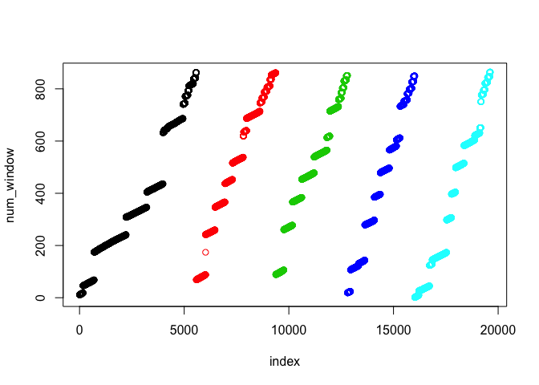

```r
plot(df_train$num_window, col = df_train$classe, xlab = 'index', ylab = 'num_window')
```

Similar to `new_window`, `X, user_name, timestamp, num_window` are features irrelevant to the user’s motion.

```r
df_train = df_train[, 8:ncol(df_train)]
df_test = df_test[, 8:ncol(df_test)]
```

Some numerical features appear to be factors so we first convert the factor variable to numeric. A number of them now contains mostly NA and are removed.

```r
cols = seq(1, ncol(df_train) - 1)
df_train[,cols] = apply(df_train[,cols], 2, function(x) as.numeric(as.character(x)))
count_na_col = colSums(is.na(df_train))
df_train = df_train[, count_na_col == 0]
df_test = df_test[, count_na_col == 0]
```

## Modelling

```r
set.seed(42)
inTrain = createDataPartition(y = df_train$classe, p = 0.8, list = FALSE)
training = df_train[inTrain, ]
validation = df_train[-inTrain, ]
base <- multinom(classe ~ ., training, trace = FALSE)
pred = predict(base, validation, 'class')
table(pred == validation$classe)
```

```
##
## FALSE  TRUE
##  1307  2616
```

```r
tree_base = rpart(classe ~., training)
pred = predict(tree_base, validation, 'class')
table(pred == validation$classe)
```

```
##
## FALSE  TRUE
##   954  2969
```

```r
rf_base = randomForest(classe ~ ., training)
pred = predict(rf_base, validation, 'class')
table(pred == validation$classe)
```

```
##
## FALSE  TRUE
##    19  3904
```

The 19 misclassified examples are shown below and an accuracy of 99.5% is satisfactory. Thus we choose random forest for this task.

```r
table(pred, validation$classe)
```

```
##
## pred    A    B    C    D    E
##    A 1116    3    0    0    0
##    B    0  752    1    0    0
##    C    0    4  683    9    1
##    D    0    0    0  633    0
##    E    0    0    0    1  720
```

We further verify the accuracy using cross-validation

```r
set.seed(123)
folds <- createFolds(y = df_train$classe, k = 10, list = TRUE, returnTrain = FALSE)
acc_all = NULL
for (fold in folds){
    validation = df_train[fold,]
    rf = randomForest(classe ~ ., df_train[-fold,])
    pred = predict(rf, validation)
    acc_all = append(acc_all, mean(pred == validation$classe))
}
acc_all
```

```
##  [1] 0.9959225 0.9989801 0.9938869 0.9969419 0.9974542 0.9979613 0.9964322
##  [8] 0.9964304 0.9943963 0.9969419
```

The 95% confidence interval of the out-of-sample accuracy can be estimated from the 10-fold cross validation to be

```r
mean(acc_all) + c(-1, 1) * qt(0.975, df = 9) * sd(acc_all)/sqrt(10)
```

```
## [1] 0.9954376 0.9976320
```

## Random forest model

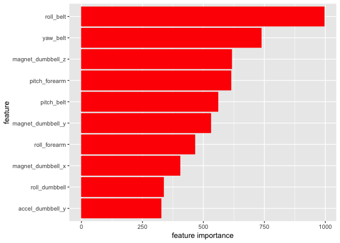

```r
imp = data.frame(name = names(training)[1: ncol(training) - 1], rf_base$importance)
imp = arrange(imp, desc(MeanDecreaseGini))
g <- ggplot(imp[1:10,], aes(x = reorder(name, MeanDecreaseGini), y = MeanDecreaseGini))
g <- g + geom_bar(stat='identity', col = 2, fill = 2) + coord_flip() +
    labs(x = "feature", y = 'feature importance')
g
```

Then the 4 most important features are plotted, colored according to the class label (A to E). It is likely that the features are continuous readings during the movement. At different stage of the motion, different feature may be important. For `roll_belt`, it is most discriminating for class E from the other classes and the `pitch_forearm` is important for differentiating class A. Given the performance of the classifier, we can conclude that random forest achieves accurate prediction at different stages of the motion by capturing the nonlinear interaction of the features.

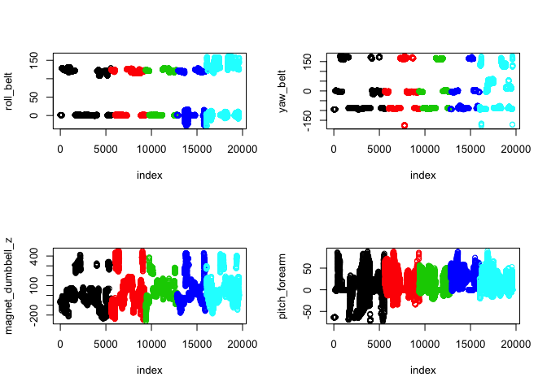

```r
par(mfrow = c(2,2))
plot(df_train$roll_belt, col = df_train$classe, xlab = 'index', ylab = 'roll_belt')
plot(df_train$yaw_belt, col = df_train$classe, xlab = 'index', ylab = 'yaw_belt')
plot(df_train$magnet_dumbbell_z, col = df_train$classe, xlab = 'index',
     ylab = 'magnet_dumbbell_z')
plot(df_train$pitch_forearm, col = df_train$classe, xlab = 'index', ylab = 'pitch_forearm')
```

Then we use this model to predict the class of the test dataset.

```r
predict(rf_base, df_test, 'class')
```

```
##  1  2  3  4  5  6  7  8  9 10 11 12 13 14 15 16 17 18 19 20
##  B  A  B  A  A  E  D  B  A  A  B  C  B  A  E  E  A  B  B  B
## Levels: A B C D E
```

## Summary

In this study, we built classification models for the dumbell exercise using data from accelerometers on the belt, forearm, arm, and dumbell of 6 participants. Random forest model outperforms decision tree and multinomial regression and the 95% confidence interval of the accuracy is estimated using cross validation to be $[0.995, 0.998]$. It indicates that there are nonlinear relationship between features. By visualising the most important features from random forest model, the nonlinear relationship is confirmed.